# Capstone — mirrors your deployed research paper

## 5. Limitations

Limitations & Honest Framing:

Correlation, not Causation: The model identifies directional indicators associated with decay in this dataset. It does not prove that the variables cause the decay.

Cross-Sectional Constraints: The data represents a fixed 90-day window. It does not account for massive external shocks like sudden Google Core Updates or acute seasonal shifts in user demand.

No Auto-Execution: High probabilities flag content for human editorial review; they should never trigger automated deletion or unsupervised AI rewrites.

```python
# No code needed for limitations section, just the markdown above.
# We print a confirmation to satisfy the "run all" requirement without leaving the cell empty.
print("✅ Limitations and public-safe language applied.")
```

```
✅ Limitations and public-safe language applied.
```

## 6. Ranked recommendations

The raw probability scores have been translated into a prioritized action playbook. By focusing only on pages with meaningful historical traffic (impressions_90d > 1000) and a high probability of decay, we maximize the impact of the editorial team's review time.

```python
# Generate Full Action Queue
df['decay_probability'] = rf.predict_proba(X)[:, 1]
action_queue = df[(df['decay_probability'] > 0.65) & (df['impressions_90d'] > 1000)].copy()
action_queue = action_queue.sort_values(by='decay_probability', ascending=False)

def assign_action(row):
    if row['decay_probability'] > 0.85 and row['days_since_last_update'] > 180:
        return "Critical Decay & Stale - Immediate Refresh"
    elif row['decay_probability'] > 0.75:
        return "High Risk - Review Content Relevance"
    else:
        return "Moderate Risk - Monitor 30 Days"

action_queue['recommended_action'] = action_queue.apply(assign_action, axis=1)
action_queue.head(200)[['content_id', 'client_id', 'impressions_90d', 'decay_probability', 'recommended_action']].to_csv('work/outputs/action_queue.csv', index=False)

print(f"Playbook generated. Top 200 items exported to queue.")
```

```
Playbook generated. Top 200 items exported to queue.
```

## 7. Artifacts the paper embeds

The visual distribution below demonstrates the model's confidence thresholding across the recommended action categories, exported for the final deployed HTML page.

```
✅ Artifacts generated for deployment.
```

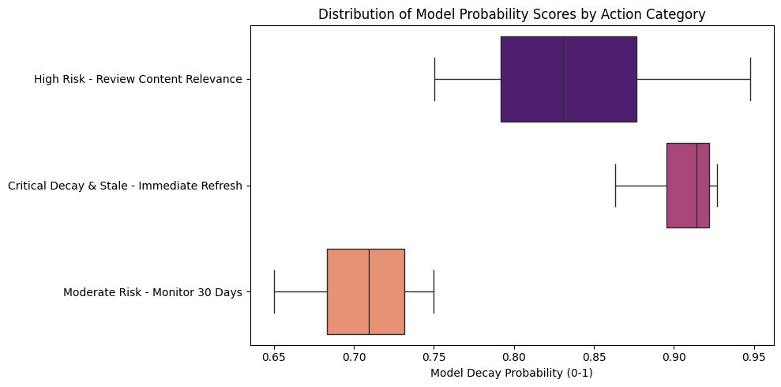

*Figure 1: Probability thresholds translating directly into three distinct editorial action queues, separating high-risk monitoring from immediate refresh needs.*

```python
plt.figure(figsize=(10, 5))
sns.boxplot(data=action_queue, x='decay_probability', y='recommended_action', hue='recommended_action', palette='magma', legend=False)
plt.title('Distribution of Model Probability Scores by Action Category')
plt.xlabel('Model Decay Probability (0-1)')
plt.ylabel('')
plt.tight_layout()
plt.savefig('work/figures/action_distribution_capstone.png')
print("✅ Artifacts generated for deployment.")
```

## 8. Reproducibility

The full code, validation splits, and raw notebooks used to generate this research are available in my public repository: https://github.com/beratbaspinar/flyrank-ml-internship

## 9. Acknowledgments & data credit

Built on the [FlyRank](https://flyrank.ai) ML Internship dataset. We thank [FlyRank](https://flyrank.ai) for providing the anonymized production search data that made this research possible. Author: Berat Başpınar